# Semester Project: Final Paper

Trinity Smith

4/27/2023

### Introduction

In a political science course I took last semester, we learned that the two strongest correlates with US presidential election outcomes are 1) the state of the economy prior to the election, and 2) how long the current party in office has held power. In my project, I will seek to evaluate how these factors have correlated with election outcomes since 1960.

### Data Description

The datasets used in this study are derived from two sources: The World Bank and CQPress. The World Bank provides the GDP per capita growth data, while CQPress offers election data, including the political party of each president and their time in office. The dataset contains these observations for each president since 1960 (party and time in office), along with the associated GDP growth for the election years.

```r
library(readr)
library(readxl)
library("dplyr")
presidents <- read_csv("Presidents.csv")
gdp <- read_excel("GDP.xlsx")

presidents$ElectionYear <- as.numeric(sapply(strsplit(presidents$StartDate, "/"), function(x) x[3]))

# Filter for years 1960 and later
presidents <- presidents[presidents$ElectionYear >= 1960, ]

elections <- data.frame()
# Iterate through the original data frame, adding a new row for each term the president served
for (i in 1:nrow(presidents)) {
  president <- presidents[i,]
  num_terms <- as.integer(president$ConsecutiveTermsServed)
  for (j in 1:num_terms) {
    new_row <- president
    new_row$ConsecutiveTermsServed <- j
    new_row$ElectionYear <- (j-1)*4+president$ElectionYear
    elections <- rbind(elections, new_row)
  }
}
presidents <- elections

# Calculate terms for the current party
presidents$PartyTerms <- 1
presidents$incumbent_won
```

```r
for (i in 2:nrow(presidents)) {
  if (presidents$PartyAbbrev[i] == presidents$PartyAbbrev[i - 1]) {
    presidents$PartyTerms[i] <- presidents$PartyTerms[i - 1] + 1
  } else {
    presidents$PartyTerms[i] <- 1
  }
}

presidents$IncumbentPartyTerms <- c(2, head(presidents$PartyTerms, -1))



# Extract GDP growth rate for the election years
gdp$Year <- as.integer(gdp$Year)
gdp$Growth <- as.numeric(gsub("%", "", gdp$Growth))

election_gdp <- gdp[gdp$Year %in% presidents$ElectionYear, c("Year", "Growth")]

# Merge datasets
election_data <- merge(presidents, election_gdp, by.x = "ElectionYear", by.y = "Year")


# Create final table
final_table <- election_data[, c("ElectionYear", "IncumbentPartyTerms", "Growth", "PartyAbbrev")]
colnames(final_table) <- c("Election Year", "Incumbent Party Terms", "GDP Growth", "Winning Party")
final_table
```

```
##    Election Year Incumbent Party Terms GDP Growth Winning Party
## 1           1961                     2     0.0230             D
## 2           1963                     1     0.0440             D
## 3           1967                     2     0.0250             D
## 4           1969                     3     0.0310             R
## 5           1974                     1    -0.0054             R
## 6           1977                     2     0.0462             D
## 7           1981                     1     0.0254             R
## 8           1985                     1     0.0417             R
## 9           1989                     2     0.0367             R
## 10          1993                     3     0.0275             D
## 11          1997                     1     0.0445             D
## 12          2001                     2     0.0095             R
## 13          2005                     1     0.0348             R
## 14          2009                     2    -0.0260             D
## 15          2013                     1     0.0184             D
## 16          2017                     2     0.0226             R
## 17          2021                     1     0.0567             D
```

### Descriptive Analyses

I’m seeking to assess the potential effects of recent GDP performance and incumbency of the current political party in office with election outcomes (R or D). My independent variables are therefore GDP performance and incumbency, and my dependent variable is election outcome. This section includes various representations to show the distributions of the variables and relationships between these them.

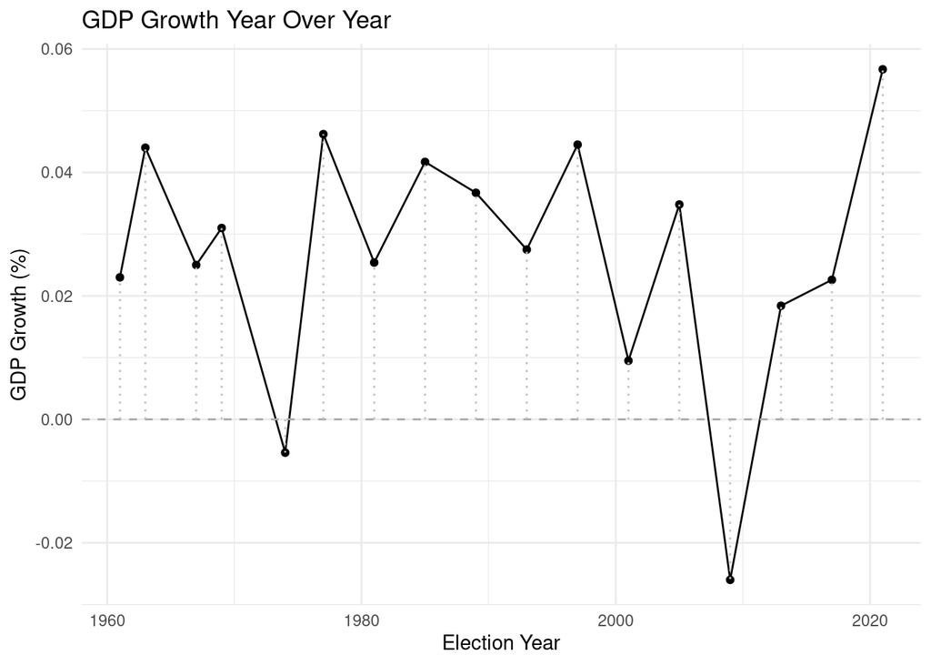

```r
library(ggplot2)

ggplot(final_table, aes(x = `Election Year`, y = `GDP Growth`)) +
  geom_point() +
  geom_line() +
  geom_hline(yintercept = 0, linetype = "dashed", color = "darkgray") +
  geom_segment(aes(x = `Election Year`, y = 0, xend = `Election Year`, yend = `GDP Growth`), linetype = "dotted", color = "gray") +
  labs(title = "GDP Growth Year Over Year",
       x = "Election Year",
       y = "GDP Growth (%)") +
  theme_minimal()
```

The plot shows the annual GDP growth for the election years since 1960. We can observe some fluctuations in GDP growth, but a more in-depth analysis in the main analyses section will help us understand the relationship between GDP growth and election outcomes.

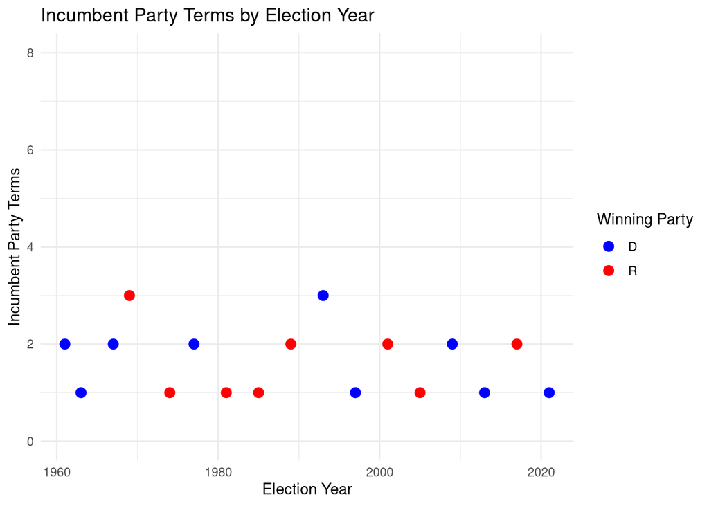

```r
ggplot(final_table, aes(x = `Election Year`, y = `Incumbent Party Terms`, color = `Winning Party`)) +
  geom_point(size = 3) +
  labs(title = "Incumbent Party Terms by Election Year",
       x = "Election Year",
       y = "Incumbent Party Terms") +
  scale_color_manual(name = "Winning Party", values = c("D" = "blue", "R" = "red")) +
  coord_cartesian(ylim = c(0, 8)) +
  theme_minimal()
```

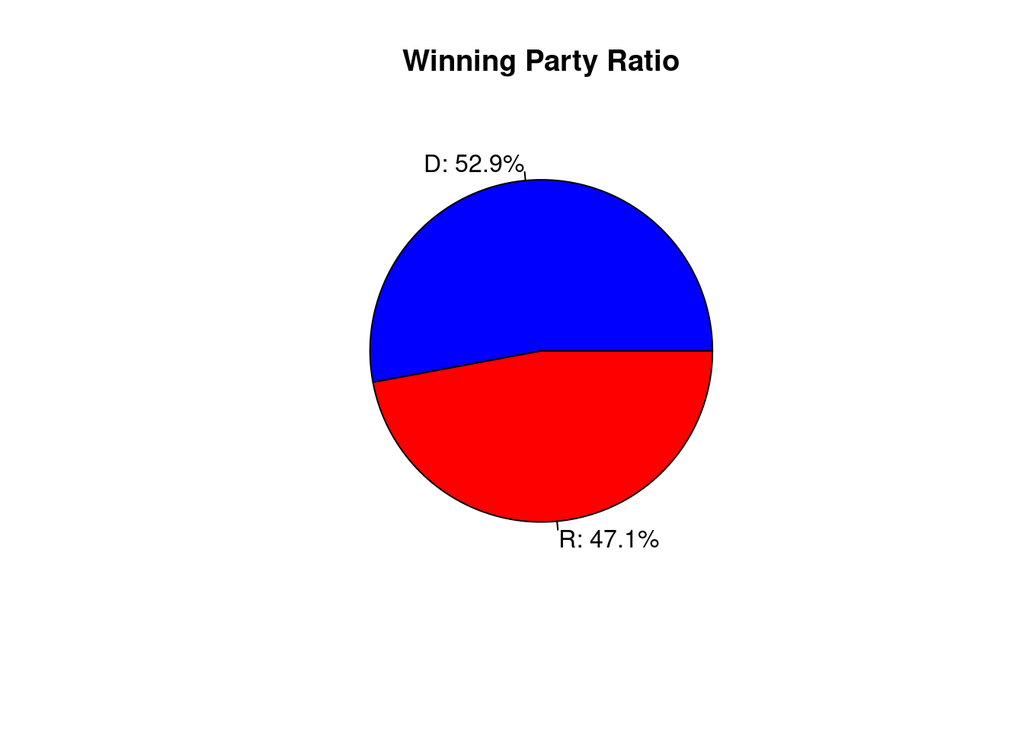

```r
winning_party_counts <- table(final_table$`Winning Party`)
winning_party_ratio <- winning_party_counts / sum(winning_party_counts)

pie(winning_party_ratio,
    labels = paste0(names(winning_party_ratio), ": ", round(winning_party_ratio * 100, 1), "%"),
    main = "Winning Party Ratio",
    col = c("blue", "red"))
```

The winning party ratio indicates the proportion of elections won by each party since 1960.

### Main Analyses

The main analysis of this study will involve determining the relationship between recent GDP growth (in election year) and the duration of the current party in power with election outcomes (R or D). Logistic regression will be the primary method of analysis. I’ll discuss the statistical and substantive significance of the results in detail.

```r
#Enter code here
library("tidyverse")
# Create the Incumbent Party column
final_table$`Incumbent Party` <- c('R', final_table$`Winning Party`[-nrow(final_table)])

# Create new predictor variables
final_table$won_only_last_election <- as.numeric(final_table$`Incumbent Party Terms` == 1)
final_table$won_two_elections <- as.numeric(final_table$`Incumbent Party Terms` >= 2)

# Create binary response variable for incumbent winning
final_table$incumbent_won <- as.numeric(final_table$`Winning Party` == final_table$`Incumbent Party`)
```

First, I examined the relationship between incumbent party duration and election outcomes starting with won_only_last_election. The logistic regression model with won_only_last_election as the predictor variable estimates the probability of the incumbent party winning the election given that they won only the last election.

```r
model_won_only_last_election_logit <- glm(incumbent_won ~ won_only_last_election, data = final_table, family = binomial(link = "logit"))
summary(model_won_only_last_election_logit)
```

```
##
## Call:
## glm(formula = incumbent_won ~ won_only_last_election, family = binomial(link = "logit"),
##     data = final_table)
##
## Deviance Residuals:
##     Min       1Q   Median       3Q      Max
## -1.6651  -0.7090  -0.7090   0.7585   1.7344
##
## Coefficients:
##                        Estimate Std. Error z value Pr(>|z|)
## (Intercept)             -1.2528     0.8018  -1.562   0.1182
## won_only_last_election   2.3514     1.1443   2.055   0.0399 *
## ---
## Signif. codes:  0 '***' 0.001 '**' 0.01 '*' 0.05 '.' 0.1 ' ' 1
##
## (Dispersion parameter for binomial family taken to be 1)
##
##     Null deviance: 23.508  on 16  degrees of freedom
## Residual deviance: 18.532  on 15  degrees of freedom
## AIC: 22.532
##
## Number of Fisher Scoring iterations: 4
```

The estimated coefficient for won_only_last_election is 2.3514, with a standard error of 1.1443. The positive coefficient suggests that if the incumbent party has won only the last election, the probability of winning the current election increases. Since the p-value of 0.0399 is less than the standard significance level of 0.05, we can reject the null hypothesis that there is no relationship between the predictor and the binary outcome. This suggests that the incumbent party’s performance in previous elections (specifically the one immediately prior) has a significant effect on their chances of winning the current election.

The results do provide some evidence that a party’s recent election results can affect their likelihood of success in upcoming elections. This is partly consistent with “incumbency advantage” research, which has found that incumbents tend to have an advantage in elections due to factors such as name recognition and access to resources. However, much of this research has studied local or state level elections.

Next, we examine the relationship between won_two_elections and election outcomes. Here, the logistic regression model with won_two_elections as the predictor variable estimates the probability of the incumbent party winning the election given that they won at least two previous elections.

```r
model_won_two_elections_logit <- glm(incumbent_won ~ won_two_elections, data = final_table, family = binomial(link = "logit"))
summary(model_won_two_elections_logit)
```

```
##
## Call:
## glm(formula = incumbent_won ~ won_two_elections, family = binomial(link = "logit"),
##     data = final_table)
##
## Deviance Residuals:
##     Min       1Q   Median       3Q      Max
## -1.6651  -0.7090  -0.7090   0.7585   1.7344
##
## Coefficients:
##                   Estimate Std. Error z value Pr(>|z|)
## (Intercept)         1.0986     0.8165   1.346   0.1785
## won_two_elections  -2.3514     1.1443  -2.055   0.0399 *
## ---
## Signif. codes:  0 '***' 0.001 '**' 0.01 '*' 0.05 '.' 0.1 ' ' 1
##
## (Dispersion parameter for binomial family taken to be 1)
##
##     Null deviance: 23.508  on 16  degrees of freedom
## Residual deviance: 18.532  on 15  degrees of freedom
## AIC: 22.532
##
## Number of Fisher Scoring iterations: 4
```

This finding aligns with the concept of political fatigue, where voters may become dissatisfied with a party that has been in power for an extended period. Over time, the incumbent party may face increased scrutiny, be held more accountable for their policy decisions, and struggle to maintain their momentum. Additionally, voters may be more inclined to seek change and new perspectives, leading them to consider alternative parties and candidates.

I next investigate the relationship between GDP growth and election outcomes.

```r
# Fit a logistic regression model with GDP Growth as a predictor
model_gdp_growth_logit <- glm(incumbent_won ~ `GDP Growth`, data = final_table, family = binomial(link = "logit"))

# Display the model summaries
summary(model_gdp_growth_logit)
```

```
##
## Call:
## glm(formula = incumbent_won ~ `GDP Growth`, family = binomial(link = "logit"),
##     data = final_table)
##
## Deviance Residuals:
##     Min       1Q   Median       3Q      Max
## -1.3350  -1.1160  -0.7976   1.1615   1.4616
##
## Coefficients:
##              Estimate Std. Error z value Pr(>|z|)
## (Intercept)   -0.5593     0.8777  -0.637    0.524
## `GDP Growth`  16.2673    26.3226   0.618    0.537
##
## (Dispersion parameter for binomial family taken to be 1)
##
##     Null deviance: 23.508  on 16  degrees of freedom
## Residual deviance: 23.105  on 15  degrees of freedom
## AIC: 27.105
##
## Number of Fisher Scoring iterations: 4
```

The estimated coefficient for GDP Growth is 16.2673, with a standard error of 26.3226. The positive coefficient suggests that as the GDP growth increases, the probability of the incumbent party winning the election also increases. However, the z-value is 0.618, which corresponds to a p-value of 0.537. Since the p-value is greater than the standard significance level of 0.05, we fail to reject the null hypothesis that there is no relationship between the predictor and the binary outcome. This implies that, based on the available data, we cannot conclude that GDP growth is a significant predictor of an incumbent party’s electoral success.

Finally, I include all predictor variables in the logistic regression model.

```r
# Fit a logistic regression model with all predictor variables
model_all_predictors_logit <- glm(incumbent_won ~ `GDP Growth` + won_only_last_election, data = final_table, family = binomial(link = "logit"))
summary(model_all_predictors_logit)
```

```
##
## Call:
## glm(formula = incumbent_won ~ `GDP Growth` + won_only_last_election,
##     family = binomial(link = "logit"), data = final_table)
##
## Deviance Residuals:
##     Min       1Q   Median       3Q      Max
## -1.6771  -0.7109  -0.6927   0.7577   1.7329
##
## Coefficients:
##                        Estimate Std. Error z value Pr(>|z|)
## (Intercept)              -1.277      1.045  -1.222   0.2218
## `GDP Growth`              1.097     30.522   0.036   0.9713
## won_only_last_election    2.340      1.187   1.970   0.0488 *
## ---
## Signif. codes:  0 '***' 0.001 '**' 0.01 '*' 0.05 '.' 0.1 ' ' 1
##
## (Dispersion parameter for binomial family taken to be 1)
##
##     Null deviance: 23.508  on 16  degrees of freedom
## Residual deviance: 18.531  on 14  degrees of freedom
## AIC: 24.531
##
## Number of Fisher Scoring iterations: 4
```

The estimated coefficients suggest that when the incumbent party has won only the last election, there is a higher probability of winning the current election. The positive estimate of 2.340 for won_only_last_election, with a standard error of 1.187, results in a z-value of 1.970 and a p-value of 0.0488. This is statistically significant at the 0.05 level, indicating a meaningful relationship between this predictor and the incumbent party’s success in the elections.

On the other hand, the coefficient for GDP Growth remains insignificant with a z-value of 0.036 and a p-value of 0.9713. This reinforces the previous finding that GDP growth is not a significant predictor of the incumbent party’s electoral success.

While GDP growth does not appear to be a significant predictor, the number of consecutive terms the incumbent party has held office predictably influences electoral success.

### Discussion

Based on the results from the main analyses, it can be concluded that while recent quantiative national economic performance has little to no effect on election results, previous election results have significant effects. The duration of a party’s incumbency is a substantial determining factor in election outcomes: having won just a single previous term is highly beneficial to incumbent parties, while having won two or more consecutively in the prior elections is harmful to their odds of success.

To further extend this study, it would be interesting to explore other factors that may influence election outcomes, such as social issues, international relations, and candidate characteristics.